# R Notebook - COVID Cases in Northeast Colorado

Maya Reese Farmer

September 28, 2021

### Introduction

I will be demonstrating some introductory modeling and data visualization techniques using the COVID-19 data for the northeast district in Colorado. This includes Logan, Morgan, Washington, Yuma, Phillips, and Sedgwick county.

The ‘COVID19CaseData’ dataset contains over 10,000 COVID case observations and has 19 columns. The most notable variables include:

- Case Status
- Date Reported
- County
- Gender
- Age
- Race and Ethnicity
- Outcome (alive or deceased)
- Hospitalized (yes or no)
- Spec1 Test Result (positive or negative)
- Reinfection (yes or no)

|  | Disease.Name | Case.Status | Reported.Date | County | Gender | Age.yrs | Race.1 | Ethnicity | City | State | Zip.Code | Onset.Date | Onset.Date.Unavailable | Outcome | Hospitalized | Spec1.Test1.Name | Spec1.Test1.Result | Spec1.Test1.Result.Date | Re.Infection.Y.N |
| --- | --- | --- | --- | --- | --- | --- | --- | --- | --- | --- | --- | --- | --- | --- | --- | --- | --- | --- | --- |
| 1 | COVID-19 | Confirmed | 3/18/2020 | Yuma | Female | 63 | White | Not Hispanic or Latino | YUMA | Colorado | 80759 | 3/11/2020 | No | Alive | No | RT-PCR | Positive | 3/17/2020 | No |
| 2 | COVID-19 | Confirmed | 3/18/2020 | Morgan | Male | 65 | White | Not Hispanic or Latino | Weldona | Colorado | 80653 | 3/3/2020 | No | Alive | No | RT-PCR | Positive | 3/18/2020 | No |
| 3 | COVID-19 | Probable | 3/19/2020 | Morgan | Female | 63 | White | Not Hispanic or Latino | Weldona | Colorado | 80653 | 3/14/2020 | No | Alive | No |  |  |  | No |
| 4 | COVID-19 | Confirmed | 3/22/2020 | Logan | Male | 84 | White | Not Hispanic or Latino | Sterling | Colorado | 80751 | 3/15/2020 | No | Patient died (finding) | Yes | RT-PCR | Positive | 3/22/2020 | No |
| 5 | COVID-19 | Confirmed | 3/22/2020 | Morgan | Female | 71 | Other Race | Hispanic or Latino | Brush | Colorado | 80723 | 3/15/2020 | Yes | Alive | Yes | RT-PCR | Positive | 3/22/2020 | No |
| 6 | COVID-19 | Confirmed | 3/22/2020 | Logan | Male | 63 | White | Not Hispanic or Latino | Sterling | Colorado | 80751 | 3/12/2020 | No | Alive | No | RT-PCR | Positive | 3/22/2020 | No |

### Queries and Data Visualization

I will be querying the data to answer a series of questions using R programming language. I’ll present my findings using either tables or ggplot2 for data visualization.

#### Total COVID Cases

The first thing I want to do is determine the total number of cases in the northeast district. This should include only cases that have a ‘confirmed’ or ‘probable’ case status.

```r
## count the number of individuals in each Case Status category
count(Case.Status)
```

| x | freq |
| --- | --- |
|  | 6 |
| Confirmed | 8741 |
| Probable | 884 |
| Suspect | 856 |
| Unknown | 1 |

The output shows that there are 8741 Confirmed cases and 884 Probable cases. This means there have been a total of 9625 cases in the northeast district to date.

Next, I want to extract these confirmed and probable cases into a new data set for additional querying.

```r
COVIDData.confirmed <- subset(Covid19CaseData, Case.Status == 'Confirmed' | Case.Status == 'Probable')
attach(COVIDData.confirmed)
```

Now the COVIDDate.confirmed data table only includes those 9625 COVID cases.

#### Percent COVID Cases by Age Group

Next I want to look at the percentage of cases by age group. The age groups include <18 yo, 18-35 yo, 36-55 yo, 56-75 yo, >75 yo. By doing this, we can observe whether individuals in different age groups have been influenced differently by COVID-19.

```r
count(Age.yrs < 18)
```

| x | freq |
| --- | --- |
| FALSE | 9006 |
| TRUE | 618 |
| NA | 1 |

```r
count(Age.yrs >= 18 & Age.yrs <= 35)
```

| x | freq |
| --- | --- |
| FALSE | 6601 |
| TRUE | 3023 |
| NA | 1 |

```r
## count # of cases when Age is 36-55
count(Age.yrs >= 36 & Age.yrs <= 55)
```

| x | freq |
| --- | --- |
| FALSE | 6624 |
| TRUE | 3000 |
| NA | 1 |

```r
## count # of cases when Age is 56-75
count(Age.yrs >= 56 & Age.yrs <= 75)
```

| x | freq |
| --- | --- |
| FALSE | 7417 |
| TRUE | 2207 |
| NA | 1 |

```r
## count # of cases when Age is >75
count(Age.yrs > 75)
```

| x | freq |
| --- | --- |
| FALSE | 8848 |
| TRUE | 776 |
| NA | 1 |

We can now create a new data table using these outputs to show how cases are distributed across age groups.

```r
age.group = c("< 18 yrs","18-35 yrs","36-55 yrs","56-75 yrs","> 75 yrs","Not Specified")
number.cases = c(618,3023,3000,2207,776,1)
percent.agedata = data.frame(age.group,number.cases)
percent.agedata
```

| age.group | number.cases |
| --- | --- |
| < 18 yrs | 618 |
| 18-35 yrs | 3023 |
| 36-55 yrs | 3000 |
| 56-75 yrs | 2207 |
| > 75 yrs | 776 |
| Not Specified | 1 |

```r
## calculate percent cases by age
percent.age = (number.cases/sum(number.cases))*100
percent.age
```

```
[1]  6.42077922 31.40779221 31.16883117 22.92987013  8.06233766
[6]  0.01038961
```

```r
## attach data string to percent.agedata dataframe
percent.agedata$percent.age = percent.age
attach(percent.agedata)
```

Now that the percent cases by age data table has been created, we can visualize the data using a donut chart.

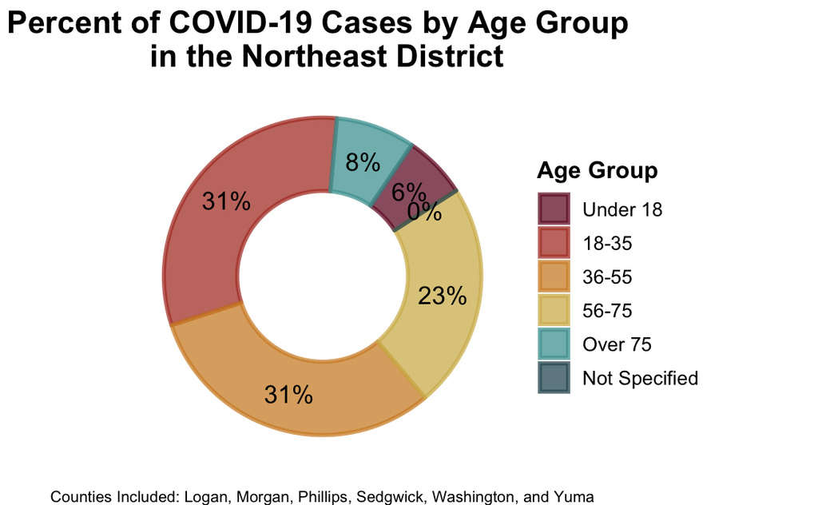

```r
library(ggplot2)
library(cowplot)

ggplot(percent.agedata, aes(x=2,y=percent.age, fill=age.group,color=age.group)) + geom_col(size=1) + coord_polar(theta="y",start = 1) +  xlim(c(0.5, 2.5)) + theme_void() + geom_text(aes(label=paste0(round(percent.age),"%")),color="black",position = position_stack(vjust = 0.5),check_overlap = T,size=4.5,show.legend = FALSE) + scale_fill_manual(values=alpha(c("#751a33","#b34233","#d28f33","#d4b95e","#4ea2a2","#335c67"),0.75),name="Age Group",breaks=c("< 18 yrs","18-35 yrs","36-55 yrs","56-75 yrs","> 75 yrs","Not Specified"), labels=c("Under 18", "18-35","36-55","56-75","Over 75","Not Specified")) + scale_color_manual(values=alpha(c("#751a33","#b34233","#d28f33","#d4b95e","#4ea2a2","#335c67"),0.75),name="Age Group",breaks=c("< 18 yrs","18-35 yrs","36-55 yrs","56-75 yrs","> 75 yrs","Not Specified"), labels=c("Under 18", "18-35","36-55","56-75","Over 75","Not Specified")) + ggtitle("Percent of COVID-19 Cases by Age Group \n in the Northeast District") + theme(plot.title = element_text(size=16,face="bold",hjust = 0.5), plot.caption = element_text(size=8,hjust = 0.5), legend.title = element_text(size=12, face="bold"), legend.text = element_text(size=10)) + labs(caption = "Counties Included: Logan, Morgan, Phillips, Sedgwick, Washington, and Yuma")
```

#### Percent COVID Cases by Race

Next, we can look at a similar breakdown of percent COVID cases based on Race.

```r
count(Race.1)
```

| x | freq |
| --- | --- |
|  | 3483 |
| American Indian or Alaska Native | 26 |
| Asian | 22 |
| Black or African American | 324 |
| Native Hawaiian or Other Pacific Islander | 16 |
| Other Race | 532 |
| Refused | 54 |
| Unknown | 436 |
| White | 4732 |

We can see from the output that Race is missing for 3483 individuals. Also, there are 2 redundant race categories: Unknown abd Refused. To make the calculations and visualization more concise, we should change the blank, Refused, and Unknown characters to a single “Not Specified” character.

```r
COVIDData.confirmed$Race.1 <- sub("^$", "Not Specified", COVIDData.confirmed$Race.1)
COVIDData.confirmed$Race.1 <- sub("Unknown", "Not Specified", COVIDData.confirmed$Race.1)
COVIDData.confirmed$Race.1 <- sub("Refused", "Not Specified", COVIDData.confirmed$Race.1)

## recount cases based on Race
count(COVIDData.confirmed$Race.1)
```

| x | freq |
| --- | --- |
| American Indian or Alaska Native | 26 |
| Asian | 22 |
| Black or African American | 324 |
| Native Hawaiian or Other Pacific Islander | 16 |
| Not Specified | 3973 |
| Other Race | 532 |
| White | 4732 |

Now that the data are cleaned up, we can create a data frame from this output which we’ll use for the next visualization.

```r
race = c("American Indian or Alaska Native","Asian","Black or African American","Native Hawaiian or Other Pacific Islander","Not Specified","Other Race","White")
cases = c(26,22,324,16,3973,532,4732)
percent.racedata = data.frame(race,cases)
percent.racedata
```

| race | cases |
| --- | --- |
| American Indian or Alaska Native | 26 |
| Asian | 22 |
| Black or African American | 324 |
| Native Hawaiian or Other Pacific Islander | 16 |
| Not Specified | 3973 |
| Other Race | 532 |
| White | 4732 |

| race | cases | percent.race |
| --- | --- | --- |
| American Indian or Alaska Native | 26 | 0.002701299 |
| Asian | 22 | 0.002285714 |
| Black or African American | 324 | 0.033662338 |
| Native Hawaiian or Other Pacific Islander | 16 | 0.001662338 |
| Not Specified | 3973 | 0.412779221 |
| Other Race | 532 | 0.055272727 |
| White | 4732 | 0.491636364 |

Now that the percent cases by Race data table has been created, we can visualize the data using a bar chart.

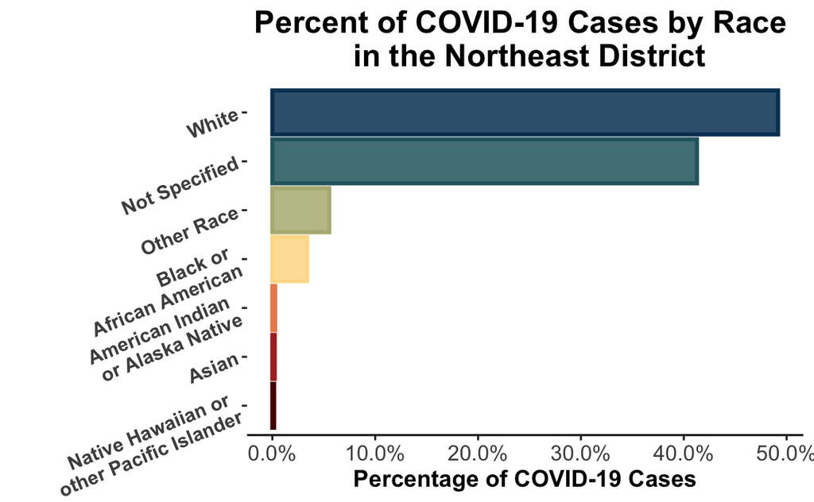

```r
ggplot(percent.racedata,aes(x=reorder(race,percent.race),y=percent.race,fill=reorder(race,percent.race),color=reorder(race,percent.race))) + geom_bar(stat = "identity",size=1) + coord_flip() + labs(x="",y="Percentage of COVID-19 Cases") + scale_fill_manual(values=alpha(c("#033f63","#28666e","#b5b682","#fedc97","#ea8c55","#ad2e24","#540804"),0.85),breaks=c("White","Not Specified","Other Race","Black or African American","American Indian or Alaska Native","Asian","Native Hawaiian or Other Pacific Islander")) + scale_color_manual(values=c("#033f63","#28666e","#b5b682","#fedc97","#ea8c55","#ad2e24","#540804"),breaks=c("White","Not Specified","Other Race","Black or African American","American Indian or Alaska Native","Asian","Native Hawaiian or Other Pacific Islander")) + scale_y_continuous(labels=percent) + ggtitle("Percent of COVID-19 Cases by Race \n in the Northeast District") + theme(panel.grid.major = element_blank(), panel.grid.minor = element_blank(), panel.background = element_blank(), plot.title = element_text(size=16,face="bold",hjust = 0.5), legend.position = "none", axis.text.y = element_text(face = "bold",size = 10, angle = 22.5), axis.title.x = element_text(face = "bold",size = 12),axis.line.x = element_line(color = "black"),axis.text.x = element_text(size=11)) +  scale_x_discrete(labels=c("Native Hawaiian or \n other Pacific Islander","Asian","American Indian \n or Alaska Native","Black or \n African American","Other Race","Not Specified","White"))
```

#### Incidence Rate per 100K by County

Finally, I want to see how the COVID incidence rate per 100K differs by county.

```r
## count the number of confirmed cases for each county
count(COVIDData.confirmed$County)
```

| x | freq |
| --- | --- |
| Logan | 4311 |
| Morgan | 3046 |
| Phillips | 451 |
| Sedgwick | 269 |
| Washington | 508 |
| Yuma | 1040 |

Now we can see the total number of confirmed cases per county.

In order to calculate incidence rate, we need to create a new data frame that includes the population for each county.

[output not shown]

I can now use the number of cases for each county and county population to calculate incidence rate.

|  | county | population | incid.county | incidence.rate |
| --- | --- | --- | --- | --- |
| 1 | Logan | 21914 | 4311 | 19672.36 |
| 2 | Morgan | 28984 | 3046 | 10509.25 |
| 3 | Phillips | 4278 | 451 | 10542.31 |
| 4 | Sedgwick | 2229 | 269 | 12068.19 |
| 5 | Washington | 4742 | 508 | 10712.78 |
| 6 | Yuma | 10063 | 1040 | 10334.89 |

Finally, we can visualize this data using a segment plot.

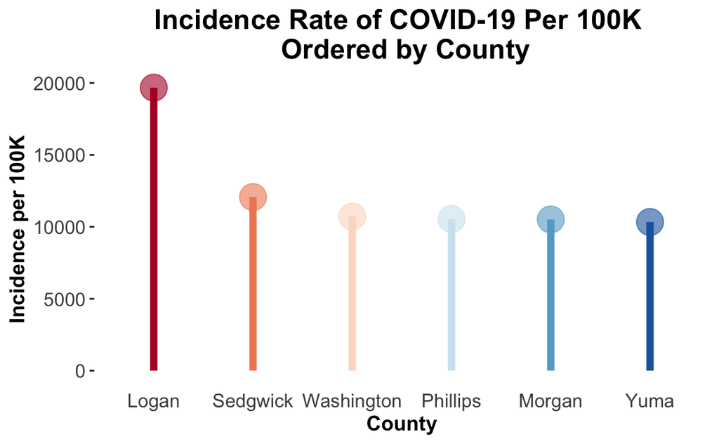

```r
ggplot(incidence, aes(x=reorder(county,-incidence.rate), y=incidence.rate,color=reorder(county,-incidence.rate),fill=reorder(county,-incidence.rate))) + geom_segment(aes(x=reorder(county,-incidence.rate), xend=reorder(county,-incidence.rate),y=0, yend=incidence.rate),size=2) + geom_point(size=7,shape=21,alpha=0.6) + labs(x="County",y="Incidence per 100K") + scale_fill_brewer(palette="RdBu") + scale_color_brewer(palette = "RdBu") + ggtitle("Incidence Rate of COVID-19 Per 100K \n Ordered by County") + theme(plot.title = element_text(size=16,face="bold",hjust = 0.5),axis.ticks.x = element_blank(),axis.text.x = element_text(size=11),axis.title.x = element_text(face="bold",size = 12),axis.title.y = element_text(face = "bold",size = 12), axis.text.y = element_text(size = 11),legend.position = "none",panel.grid.major = element_blank(),panel.grid.minor = element_blank(),panel.background = element_blank())
```